# task 2

```python
import numpy as np
import pandas as pd
import matplotlib.pyplot as plt
import seaborn as sns
from statistics import mode
%matplotlib inline
```

```python
df = pd.read_excel('C:/Users/Guoli/Documents/Data Science Material/Projects/ANZ/ANZ synthesised transaction dataset.xlsx')
```

```python
df.head()
```

|  | status | card_present_flag | bpay_biller_code | account | currency | long_lat | txn_description | merchant_id | merchant_code | first_name | ... | age | merchant_suburb | merchant_state | extraction | amount | transaction_id | country | customer_id | merchant_long_lat | movement |
| --- | --- | --- | --- | --- | --- | --- | --- | --- | --- | --- | --- | --- | --- | --- | --- | --- | --- | --- | --- | --- | --- |
| 0 | authorized | 1.0 | NaN | ACC-1598451071 | AUD | 153.41 -27.95 | POS | 81c48296-73be-44a7-befa-d053f48ce7cd | NaN | Diana | ... | 26 | Ashmore | QLD | 2018-08-01T01:01:15.000+0000 | 16.25 | a623070bfead4541a6b0fff8a09e706c | Australia | CUS-2487424745 | 153.38 -27.99 | debit |
| 1 | authorized | 0.0 | NaN | ACC-1598451071 | AUD | 153.41 -27.95 | SALES-POS | 830a451c-316e-4a6a-bf25-e37caedca49e | NaN | Diana | ... | 26 | Sydney | NSW | 2018-08-01T01:13:45.000+0000 | 14.19 | 13270a2a902145da9db4c951e04b51b9 | Australia | CUS-2487424745 | 151.21 -33.87 | debit |
| 2 | authorized | 1.0 | NaN | ACC-1222300524 | AUD | 151.23 -33.94 | POS | 835c231d-8cdf-4e96-859d-e9d571760cf0 | NaN | Michael | ... | 38 | Sydney | NSW | 2018-08-01T01:26:15.000+0000 | 6.42 | feb79e7ecd7048a5a36ec889d1a94270 | Australia | CUS-2142601169 | 151.21 -33.87 | debit |
| 3 | authorized | 1.0 | NaN | ACC-1037050564 | AUD | 153.10 -27.66 | SALES-POS | 48514682-c78a-4a88-b0da-2d6302e64673 | NaN | Rhonda | ... | 40 | Buderim | QLD | 2018-08-01T01:38:45.000+0000 | 40.90 | 2698170da3704fd981b15e64a006079e | Australia | CUS-1614226872 | 153.05 -26.68 | debit |
| 4 | authorized | 1.0 | NaN | ACC-1598451071 | AUD | 153.41 -27.95 | SALES-POS | b4e02c10-0852-4273-b8fd-7b3395e32eb0 | NaN | Diana | ... | 26 | Mermaid Beach | QLD | 2018-08-01T01:51:15.000+0000 | 3.25 | 329adf79878c4cf0aeb4188b4691c266 | Australia | CUS-2487424745 | 153.44 -28.06 | debit |

5 rows × 23 columns

The dataset contains 12043 transactions for 100 customers who have one bank account each. Trasactional period is from 01/08/2018 - 31/10/2018 (92 days duration).

```python
df.shape
```

```
(12043, 23)
```

```python
df.date.nunique()
```

```
91
```

This length shows a day is missing

```python
df.date.unique()
```

```
array(['2018-08-01T00:00:00.000000000', '2018-08-02T00:00:00.000000000',
       '2018-08-03T00:00:00.000000000', '2018-08-04T00:00:00.000000000',
       '2018-08-05T00:00:00.000000000', '2018-08-06T00:00:00.000000000',
       '2018-08-07T00:00:00.000000000', '2018-08-08T00:00:00.000000000',
       '2018-08-09T00:00:00.000000000', '2018-08-10T00:00:00.000000000',
       '2018-08-11T00:00:00.000000000', '2018-08-12T00:00:00.000000000',
       '2018-08-13T00:00:00.000000000', '2018-08-14T00:00:00.000000000',
       '2018-08-15T00:00:00.000000000', '2018-08-17T00:00:00.000000000',
       '2018-08-18T00:00:00.000000000', '2018-08-19T00:00:00.000000000',
       '2018-08-20T00:00:00.000000000', '2018-08-21T00:00:00.000000000',
       '2018-08-22T00:00:00.000000000', '2018-08-23T00:00:00.000000000',
       '2018-08-24T00:00:00.000000000', '2018-08-25T00:00:00.000000000',
       '2018-08-26T00:00:00.000000000', '2018-08-27T00:00:00.000000000',
       '2018-08-28T00:00:00.000000000', '2018-08-29T00:00:00.000000000',
       '2018-08-30T00:00:00.000000000', '2018-08-31T00:00:00.000000000',
       '2018-09-01T00:00:00.000000000', '2018-09-02T00:00:00.000000000',
       '2018-09-03T00:00:00.000000000', '2018-09-04T00:00:00.000000000',
       '2018-09-05T00:00:00.000000000', '2018-09-06T00:00:00.000000000',
       '2018-09-07T00:00:00.000000000', '2018-09-08T00:00:00.000000000',
       '2018-09-09T00:00:00.000000000', '2018-09-10T00:00:00.000000000',
       '2018-09-11T00:00:00.000000000', '2018-09-12T00:00:00.000000000',
       '2018-09-13T00:00:00.000000000', '2018-09-14T00:00:00.000000000',
       '2018-09-15T00:00:00.000000000', '2018-09-16T00:00:00.000000000',
       '2018-09-17T00:00:00.000000000', '2018-09-18T00:00:00.000000000',
       '2018-09-19T00:00:00.000000000', '2018-09-20T00:00:00.000000000',
       '2018-09-21T00:00:00.000000000', '2018-09-22T00:00:00.000000000',
       '2018-09-23T00:00:00.000000000', '2018-09-24T00:00:00.000000000',
       '2018-09-25T00:00:00.000000000', '2018-09-26T00:00:00.000000000',
       '2018-09-27T00:00:00.000000000', '2018-09-28T00:00:00.000000000',
       '2018-09-29T00:00:00.000000000', '2018-09-30T00:00:00.000000000',
       '2018-10-01T00:00:00.000000000', '2018-10-02T00:00:00.000000000',
       '2018-10-03T00:00:00.000000000', '2018-10-04T00:00:00.000000000',
       '2018-10-05T00:00:00.000000000', '2018-10-06T00:00:00.000000000',
       '2018-10-07T00:00:00.000000000', '2018-10-08T00:00:00.000000000',
       '2018-10-09T00:00:00.000000000', '2018-10-10T00:00:00.000000000',
       '2018-10-11T00:00:00.000000000', '2018-10-12T00:00:00.000000000',
       '2018-10-13T00:00:00.000000000', '2018-10-14T00:00:00.000000000',
       '2018-10-15T00:00:00.000000000', '2018-10-16T00:00:00.000000000',
       '2018-10-17T00:00:00.000000000', '2018-10-18T00:00:00.000000000',
       '2018-10-19T00:00:00.000000000', '2018-10-20T00:00:00.000000000',
       '2018-10-21T00:00:00.000000000', '2018-10-22T00:00:00.000000000',
       '2018-10-23T00:00:00.000000000', '2018-10-24T00:00:00.000000000',
       '2018-10-25T00:00:00.000000000', '2018-10-26T00:00:00.000000000',
       '2018-10-27T00:00:00.000000000', '2018-10-28T00:00:00.000000000',
       '2018-10-29T00:00:00.000000000', '2018-10-30T00:00:00.000000000',
       '2018-10-31T00:00:00.000000000'], dtype='datetime64[ns]')
```

```python
#np.where(pd.isnull(my_data['date']))
```

```python
#pd.date_range(start = '2018-08-1', end = '2018-10-31' ).difference(my_data.index)
```

```python
df.info()
```

```
<class 'pandas.core.frame.DataFrame'>
RangeIndex: 12043 entries, 0 to 12042
Data columns (total 23 columns):
 #   Column             Non-Null Count  Dtype
---  ------             --------------  -----
 0   status             12043 non-null  object
 1   card_present_flag  7717 non-null   float64
 2   bpay_biller_code   885 non-null    object
 3   account            12043 non-null  object
 4   currency           12043 non-null  object
 5   long_lat           12043 non-null  object
 6   txn_description    12043 non-null  object
 7   merchant_id        7717 non-null   object
 8   merchant_code      883 non-null    float64
 9   first_name         12043 non-null  object
 10  balance            12043 non-null  float64
 11  date               12043 non-null  datetime64[ns]
 12  gender             12043 non-null  object
 13  age                12043 non-null  int64
 14  merchant_suburb    7717 non-null   object
 15  merchant_state     7717 non-null   object
 16  extraction         12043 non-null  object
 17  amount             12043 non-null  float64
 18  transaction_id     12043 non-null  object
 19  country            12043 non-null  object
 20  customer_id        12043 non-null  object
 21  merchant_long_lat  7717 non-null   object
 22  movement           12043 non-null  object
dtypes: datetime64[ns](1), float64(4), int64(1), object(17)
memory usage: 2.1+ MB
```

```python
null_values = my_data.isnull().sum()
null_values
```

```
status                   0
card_present_flag     4326
bpay_biller_code     11158
account                  0
currency                 0
long_lat                 0
txn_description          0
merchant_id           4326
merchant_code        11160
first_name               0
balance                  0
date                     0
gender                   0
age                      0
merchant_suburb       4326
merchant_state        4326
extraction               0
amount                   0
transaction_id           0
country                  0
customer_id              0
merchant_long_lat     4326
movement                 0
dtype: int64
```

```python
null_values = null_values[null_values>0]
null_values_percentage = round(null_values/len(df), 4) * 100
pd.DataFrame({'Number of null': null_values, 'percentage': null_values_percentage}).sort_values(by = 'percentage', ascending = False)
```

|  | Number of null | percentage |
| --- | --- | --- |
| merchant_code | 11160 | 92.67 |
| bpay_biller_code | 11158 | 92.65 |
| card_present_flag | 4326 | 35.92 |
| merchant_id | 4326 | 35.92 |
| merchant_suburb | 4326 | 35.92 |
| merchant_state | 4326 | 35.92 |
| merchant_long_lat | 4326 | 35.92 |

### Exam each feature

```python
df.columns
```

```
Index(['status', 'card_present_flag', 'bpay_biller_code', 'account',
       'currency', 'long_lat', 'txn_description', 'merchant_id',
       'merchant_code', 'first_name', 'balance', 'date', 'gender', 'age',
       'merchant_suburb', 'merchant_state', 'extraction', 'amount',
       'transaction_id', 'country', 'customer_id', 'merchant_long_lat',
       'movement'],
      dtype='object')
```

### Columns 'first_name', 'customer_id'.

```python
df.first_name.value_counts()
```

[output not shown]

```python
df.customer_id.value_counts()
```

```
CUS-2487424745    578
CUS-2142601169    303
CUS-3026014945    292
CUS-3378712515    260
CUS-1614226872    259
                 ...
CUS-3395687666     40
CUS-3201519139     37
CUS-1646183815     34
CUS-495599312      31
CUS-1739931018     25
Name: customer_id, Length: 100, dtype: int64
```

'first_name' column is not much helpful here, we can delete it.

```python
df = df.drop(['first_name'], axis = 1)
```

```python
df.transaction_id.value_counts().head()
```

```
acec2cd419a54a34bfc420336fd2bdf7    1
e54f4282efd848d0b8da05f8d35654c6    1
dcf2ae387c184317910ebbe8a2e00c41    1
4c9cc84c50a04d239862be8e5a39c914    1
0389ee6fc6324663bc41e9565aa69ecb    1
Name: transaction_id, dtype: int64
```

'transaction_id' column is not help for prediction here, we can delete it.

```python
df= df.drop(['transaction_id'], axis = 1)
```

### Columns for locations.

```python
df.country.value_counts(dropna = False)
```

```
Australia    12043
Name: country, dtype: int64
```

```python
df.country.unique()
```

```
array(['Australia'], dtype=object)
```

```python
df_location = df[['long_lat', 'merchant_long_lat']]
df_location.head(3)
```

|  | long_lat | merchant_long_lat |
| --- | --- | --- |
| 0 | 153.41 -27.95 | 153.38 -27.99 |
| 1 | 153.41 -27.95 | 151.21 -33.87 |
| 2 | 151.23 -33.94 | 151.21 -33.87 |

```python
df_location[['c_long', 'c_lat']] = df_location.long_lat.str.split(' ', expand = True)
df_location.head(3)
```

|  | long_lat | merchant_long_lat | c_long | c_lat |
| --- | --- | --- | --- | --- |
| 0 | 153.41 -27.95 | 153.38 -27.99 | 153.41 | -27.95 |
| 1 | 153.41 -27.95 | 151.21 -33.87 | 153.41 | -27.95 |
| 2 | 151.23 -33.94 | 151.21 -33.87 | 151.23 | -33.94 |

```python
df_location[['m_long', 'm_lat']] = df_location.merchant_long_lat.str.split(' ', expand = True)
df_location.head(3)
```

|  | long_lat | merchant_long_lat | c_long | c_lat | m_long | m_lat |
| --- | --- | --- | --- | --- | --- | --- |
| 0 | 153.41 -27.95 | 153.38 -27.99 | 153.41 | -27.95 | 153.38 | -27.99 |
| 1 | 153.41 -27.95 | 151.21 -33.87 | 153.41 | -27.95 | 151.21 | -33.87 |
| 2 | 151.23 -33.94 | 151.21 -33.87 | 151.23 | -33.94 | 151.21 | -33.87 |

```python
df_location[['c_long', 'c_lat', 'm_long', 'm_lat']] = df_location[['c_long', 'c_lat', 'm_long', 'm_lat']].apply(pd.to_numeric)
```

```python
df = df.join(df_location[['c_long', 'c_lat', 'm_long', 'm_lat']])
```

```python
df.head(2)
```

|  | status | card_present_flag | bpay_biller_code | account | currency | long_lat | txn_description | merchant_id | merchant_code | balance | ... | extraction | amount | country | customer_id | merchant_long_lat | movement | c_long | c_lat | m_long | m_lat |
| --- | --- | --- | --- | --- | --- | --- | --- | --- | --- | --- | --- | --- | --- | --- | --- | --- | --- | --- | --- | --- | --- |
| 0 | authorized | 1.0 | NaN | ACC-1598451071 | AUD | 153.41 -27.95 | POS | 81c48296-73be-44a7-befa-d053f48ce7cd | NaN | 35.39 | ... | 2018-08-01T01:01:15.000+0000 | 16.25 | Australia | CUS-2487424745 | 153.38 -27.99 | debit | 153.41 | -27.95 | 153.38 | -27.99 |
| 1 | authorized | 0.0 | NaN | ACC-1598451071 | AUD | 153.41 -27.95 | SALES-POS | 830a451c-316e-4a6a-bf25-e37caedca49e | NaN | 21.20 | ... | 2018-08-01T01:13:45.000+0000 | 14.19 | Australia | CUS-2487424745 | 151.21 -33.87 | debit | 153.41 | -27.95 | 151.21 | -33.87 |

2 rows × 25 columns

```python
df_temp = df.loc[(df['c_long']>113)&(df['c_long']<154)&(df['c_lat']>-44)&(df['c_lat']<-10)]
```

```python
df_temp.customer_id.nunique()
```

```
99
```

Location infomation suggested there is one customer who resides outside Australia. However, all his/her transaction histories occured within AU thus these records are included for further analysis

```python
#df.apply(lambda x: len(x.unique()))
```

```python
df = df.drop(['bpay_biller_code', 'merchant_id', 'merchant_code'], axis = 1)
```

```python
df.head(2)
```

|  | status | card_present_flag | account | currency | long_lat | txn_description | balance | date | gender | age | ... | extraction | amount | country | customer_id | merchant_long_lat | movement | c_long | c_lat | m_long | m_lat |
| --- | --- | --- | --- | --- | --- | --- | --- | --- | --- | --- | --- | --- | --- | --- | --- | --- | --- | --- | --- | --- | --- |
| 0 | authorized | 1.0 | ACC-1598451071 | AUD | 153.41 -27.95 | POS | 35.39 | 2018-08-01 | F | 26 | ... | 2018-08-01T01:01:15.000+0000 | 16.25 | Australia | CUS-2487424745 | 153.38 -27.99 | debit | 153.41 | -27.95 | 153.38 | -27.99 |
| 1 | authorized | 0.0 | ACC-1598451071 | AUD | 153.41 -27.95 | SALES-POS | 21.20 | 2018-08-01 | F | 26 | ... | 2018-08-01T01:13:45.000+0000 | 14.19 | Australia | CUS-2487424745 | 151.21 -33.87 | debit | 153.41 | -27.95 | 151.21 | -33.87 |

2 rows × 22 columns

```python
df.currency.unique()
```

```
array(['AUD'], dtype=object)
```

```python
df = df.drop(['account', 'country', 'currency'], axis = 1)
```

```python
df.isnull().sum().sort_values(ascending = False)
```

```
merchant_state       4326
merchant_suburb      4326
m_long               4326
merchant_long_lat    4326
card_present_flag    4326
m_lat                4326
gender                  0
age                     0
date                    0
balance                 0
extraction              0
amount                  0
customer_id             0
txn_description         0
movement                0
c_long                  0
c_lat                   0
long_lat                0
status                  0
dtype: int64
```

Missing values in the above columns all originate from non-purchases transactions.

```python
cols = ['card_present_flag', 'merchant_state', 'merchant_suburb', 'merchant_long_lat', 'm_long', 'm_lat']
for col in cols:
    df[col].fillna("n/a", inplace = True)
```

```python
df.isnull().sum()
```

```
status               0
card_present_flag    0
long_lat             0
txn_description      0
balance              0
date                 0
gender               0
age                  0
merchant_suburb      0
merchant_state       0
extraction           0
amount               0
customer_id          0
merchant_long_lat    0
movement             0
c_long               0
c_lat                0
m_long               0
m_lat                0
dtype: int64
```

### Response variable(annual salary)

```python
df.customer_id.nunique()
```

```
100
```

```python
df.customer_id[0]
```

```
'CUS-2487424745'
```

```python
customer_0 = df.loc[(df.customer_id == df.customer_id[0])& (df.txn_description == 'PAY/SALARY')].groupby('date', as_index =False)['amount'].sum()
customer_0
```

|  | date | amount |
| --- | --- | --- |
| 0 | 2018-08-01 | 1013.67 |
| 1 | 2018-08-08 | 1013.67 |
| 2 | 2018-08-15 | 1013.67 |
| 3 | 2018-08-22 | 1013.67 |
| 4 | 2018-08-29 | 1013.67 |
| 5 | 2018-09-05 | 1013.67 |
| 6 | 2018-09-12 | 1013.67 |
| 7 | 2018-09-19 | 1013.67 |
| 8 | 2018-09-26 | 1013.67 |
| 9 | 2018-10-03 | 1013.67 |
| 10 | 2018-10-10 | 1013.67 |
| 11 | 2018-10-17 | 1013.67 |
| 12 | 2018-10-24 | 1013.67 |
| 13 | 2018-10-31 | 1013.67 |

#### Get all customers salary payment

```python
df_salary = pd.DataFrame(df.customer_id.unique(), columns = ['customer_id'])
df_salary
```

|  | customer_id |
| --- | --- |
| 0 | CUS-2487424745 |
| 1 | CUS-2142601169 |
| 2 | CUS-1614226872 |
| 3 | CUS-2688605418 |
| 4 | CUS-4123612273 |
| ... | ... |
| 95 | CUS-2505971401 |
| 96 | CUS-2819545904 |
| 97 | CUS-3395687666 |
| 98 | CUS-1147642491 |
| 99 | CUS-261674136 |

100 rows × 1 columns

#### Create annual salary column

```python
df_amount = []
pay_times = []
for customer in range(df.customer_id.nunique()):
    customer_salary =  df.loc[(df.customer_id == df.customer_id[customer])& (df.txn_description == 'PAY/SALARY')].groupby('date', as_index =False)['amount'].sum()
    count = len(customer_salary)
    pay_times.append(count)
    if count == 0:
        df_amount.append(np.nan)
    else:
        df_amount.append(mode(customer_salary.amount))

df_salary["salary_amount"] = df_amount
df_salary["annual_salary"] = df_salary["salary_amount"] * pay_times * 365/92
df_salary.head()
```

|  | customer_id | salary_amount | annual_salary |
| --- | --- | --- | --- |
| 0 | CUS-2487424745 | 1013.67 | 56302.757609 |
| 1 | CUS-2142601169 | 1013.67 | 56302.757609 |
| 2 | CUS-1614226872 | 1002.13 | 51685.944022 |
| 3 | CUS-2688605418 | 892.09 | 46010.511413 |
| 4 | CUS-4123612273 | 1013.67 | 56302.757609 |

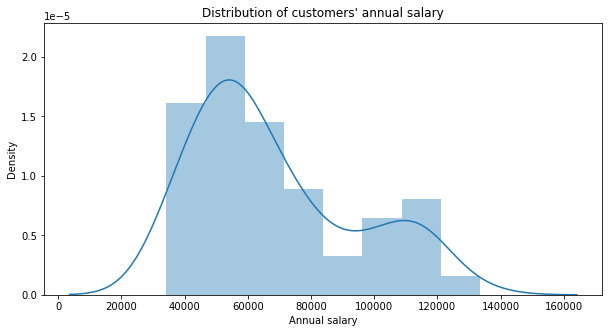

```python
plt.figure(figsize = (10, 5))
sns.distplot(df_salary.annual_salary)
plt.title("Distribution of customers' annual salary")
plt.xlabel("Annual salary")
```

#### Age and gender features for each customer

```python
df.customer_id.nunique()
```

```
100
```

```python
id = df.customer_id.unique()
len(id)
```

```
100
```

```python
age = []
gender = []
for customer in id:
    array_age = df.loc[df['customer_id']==customer, 'age']
    array_gender = df.loc[df['customer_id']==customer, 'gender']
    age.append(mode(array_age))
    gender.append(mode(array_gender))



print(age[:5])
print(gender[:5])
```

```
[26, 38, 40, 20, 43]
['F', 'M', 'F', 'M', 'F']
```

#### Merchant state feature

```python
state = []
for customer in id:
    array_state = df.loc[df['customer_id'] == customer, 'merchant_state']
    state.append(mode(array_state))
state[:5]
```

```
['QLD', 'NSW', 'QLD', 'NSW', 'VIC']
```

#### Maximum transaction amount

```python
max_amount = []
for customer in id:
    array_amount = df.loc[df['customer_id']==customer, 'amount']
    max_amount.append(max(array_amount))
max_amount[:5]
```

```
[1452.21, 2349.55, 892.09, 2320.3, 1068.04]
```

#### Average transaction amount

```python
avg_trans_amount = []
for customer in id:
    array_avgamount = df.loc[df['customer_id'] == customer, "amount"]
    avg_trans_amount.append(array_avgamount.mean())
avg_trans_amount[:5]
```

```
[45.34877162629756,
 78.20610561056101,
 74.46501930501928,
 159.3041860465116,
 166.50835820895517]
```

```python
df_new = pd.DataFrame({'customer_id': id,
              'age': age,
              'gender': gender,
              'max_trans_amount': max_amount,
              'avg_trans_amount': avg_trans_amount,
               'merchant_state': state,
               'annual_salary': df_salary.annual_salary})

df_new.head()
```

|  | customer_id | age | gender | max_trans_amount | avg_trans_amount | merchant_state | annual_salary |
| --- | --- | --- | --- | --- | --- | --- | --- |
| 0 | CUS-2487424745 | 26 | F | 1452.21 | 45.348772 | QLD | 56302.757609 |
| 1 | CUS-2142601169 | 38 | M | 2349.55 | 78.206106 | NSW | 56302.757609 |
| 2 | CUS-1614226872 | 40 | F | 892.09 | 74.465019 | QLD | 51685.944022 |
| 3 | CUS-2688605418 | 20 | M | 2320.30 | 159.304186 | NSW | 46010.511413 |
| 4 | CUS-4123612273 | 43 | F | 1068.04 | 166.508358 | VIC | 56302.757609 |

```python
df_new.isnull().sum()
```

```
customer_id         0
age                 0
gender              0
max_trans_amount    0
avg_trans_amount    0
merchant_state      0
annual_salary       0
dtype: int64
```

```python
df_new.merchant_state.unique()
```

```
array(['QLD', 'NSW', 'VIC', 'WA', 'n/a', 'NT'], dtype=object)
```

```python
catg_values = df_new[['gender', 'merchant_state']].values
catg_values[:5]
```

```
array([['F', 'QLD'],
       ['M', 'NSW'],
       ['F', 'QLD'],
       ['M', 'NSW'],
       ['F', 'VIC']], dtype=object)
```

```python
from sklearn import preprocessing
le_gender = preprocessing.LabelEncoder()
le_gender.fit(['F','M'])
catg_values[:,0] = le_gender.transform(catg_values[:,0])


le_state = preprocessing.LabelEncoder()
le_state.fit(['QLD', 'NSW', 'VIC', 'WA', 'n/a', 'NT'])
catg_values[:,1] = le_state.transform(catg_values[:,1])

catg_values[:5]
```

```
array([[0, 2],
       [1, 0],
       [0, 2],
       [1, 0],
       [0, 3]], dtype=object)
```

```python
pd.DataFrame(catg_values, columns = ['gender_value', 'state_value']).head()
```

|  | gender_value | state_value |
| --- | --- | --- |
| 0 | 0 | 2 |
| 1 | 1 | 0 |
| 2 | 0 | 2 |
| 3 | 1 | 0 |
| 4 | 0 | 3 |

```python
df_new = df_new.join(pd.DataFrame(catg_values, columns = ['gender_value', 'state_value']))
df_new.head()
```

|  | customer_id | age | gender | max_trans_amount | avg_trans_amount | merchant_state | annual_salary | gender_value | state_value |
| --- | --- | --- | --- | --- | --- | --- | --- | --- | --- |
| 0 | CUS-2487424745 | 26 | F | 1452.21 | 45.348772 | QLD | 56302.757609 | 0 | 2 |
| 1 | CUS-2142601169 | 38 | M | 2349.55 | 78.206106 | NSW | 56302.757609 | 1 | 0 |
| 2 | CUS-1614226872 | 40 | F | 892.09 | 74.465019 | QLD | 51685.944022 | 0 | 2 |
| 3 | CUS-2688605418 | 20 | M | 2320.30 | 159.304186 | NSW | 46010.511413 | 1 | 0 |
| 4 | CUS-4123612273 | 43 | F | 1068.04 | 166.508358 | VIC | 56302.757609 | 0 | 3 |

```python
x = df_new.drop(['customer_id','gender', 'merchant_state', 'annual_salary'], axis = 1)
y = df_new.annual_salary
```

```python
x.head(2)
```

|  | age | max_trans_amount | avg_trans_amount | gender_value | state_value |
| --- | --- | --- | --- | --- | --- |
| 0 | 26 | 1452.21 | 45.348772 | 0 | 2 |
| 1 | 38 | 2349.55 | 78.206106 | 1 | 0 |

```python
y[:2]
```

```
0    56302.757609
1    56302.757609
Name: annual_salary, dtype: float64
```

```python
from sklearn.model_selection import train_test_split
```

```python
x_train, x_test, y_train, y_test = train_test_split(x, y, test_size = 0.2, random_state = 9)
```

### Simple linear regression model

```python
from sklearn import linear_model
regr = linear_model.LinearRegression()
regr.fit(x_train, y_train)
```

```
LinearRegression()
```

```python
# The coefficients
print ('Coefficients: ', regr.coef_)
print ('Intercept: ',regr.intercept_)
```

```
Coefficients:  [-3.56715405e+01  1.15888338e+00  3.83212519e+00 -3.35276521e+03
  7.37680845e+02]
Intercept:  67258.86761936238
```

```python
### Evaluation

from sklearn.metrics import r2_score
from sklearn.metrics import mean_squared_error

Y_test = regr.predict(x_test)

print("Mean absolute error: %.2f" % np.mean(np.absolute(Y_test- y_test)))
print("Residual mean squares (RMSE): %.2f" % np.sqrt(mean_squared_error(y_test, Y_test)))
print("R2-score: %.2f" % r2_score(Y_test , y_test) )
```

```
Mean absolute error: 19262.67
Residual mean squares (RMSE): 23260.91
R2-score: -35.69
```

### Decision Tree Model

```python
from sklearn.tree import DecisionTreeRegressor
```

```python
tree = DecisionTreeRegressor(random_state = 0)
tree.fit(x_train.values, y_train.values)
```

```
DecisionTreeRegressor(random_state=0)
```

#### Prediction

```python
predtree = tree.predict(x_test.values)
```

```python
print(predtree[:5])
print(y_test.values[:5])
```

```
[117086.76304348  71454.18532609  78875.9048913   43833.80217391
  48459.5423913 ]
[97690.14728261 52815.42065217 59510.86956522 39104.83043478
 46010.51141304]
```

```python
### Evaluation

print("RMSE: %.2f" % np.sqrt(mean_squared_error(y_test, predtree)))
```

```
RMSE: 29003.55
```

```python
print('Accuracy on training set: {:.3f}'.format(tree.score(x_train, y_train)))
print('Accuracy on testing set:{:.3f}'.format(tree.score(x_test, y_test)))
```

```
Accuracy on training set: 1.000
Accuracy on testing set:-0.909
```

### Conclusion

1) The RMSE for both models are over $20,000 and although regression model performed better than decision tree by having a smaller RMSE, both models still appear to be highly inaccurate. Therefore, it is risky to use them to predict customers' income bracket. More data is required to develop a more reliable model. 2) Or it could be the feature selection was done very wrong since r2 score and tree.score are negative which means the models can be arbitrarily worse.